# NYC taxi trip duration analysis

Chengliang Tang and Zhi Wang

12/2/2017

# A basic view

Our data is based on the 2016 NYC Yellow Cab trip record data made available in Big Query on Google Cloud Platform (downloaded from https://www.kaggle.com/c/nyc-taxi-trip-duration). The training set contains 1.46 millon samples, with features like datetime, geographic info (latitude, longitude) of pickup and dropoff for each sample. There are some other features provided, for example, syncronization of trip record, vendor id, etc., which has low correlation with duration and may not be included in our models. An interesting job is to explore how those features can affect the trip duration. We did some visualization and used tree-based models for prediction.

To begin with, we first plot pickup (blue) and dropoff (green) locations of 5000 randomly selected samples. The majority of trips take place in Manhanttan; another two hot spots are LagGuardia and JFK airports.

[interactive chart not shown]

The most influential factor of trip duration, in common sense, is the distance. As almost all of the trips in our dataset take place in Manhatten only, Manhatten (L1) distance can be a good choice for a crude analysis. Also, the small scope of trips permits us to ignore the spherical effects and we transfrom distance into kilometers by multiplying some constants over longitudes (latitudes). Those trips which start from one side of the central park and end at right the opposite side cannot be measured well by Manhatten distance, yet only take a small proportion in the training set.

To get the right distance, we take into account that the avenues of Manhattan deviate from true north. Through some simple calculations we rotate the coordinates by 29 degree and convert them into Manhatten distance in kilometers.

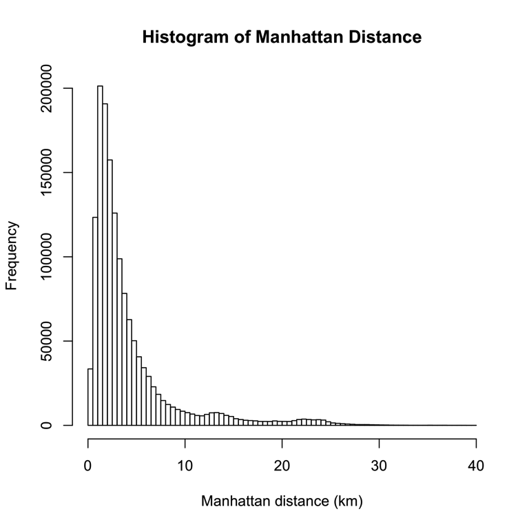

# Outliers

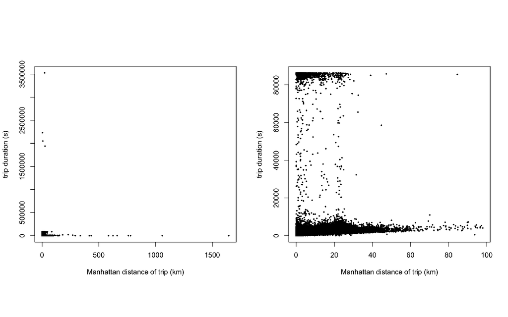

# Effects of factors

The red line in the left figure below is simple linear regression, it grasps the positive correlation but the noise is very large. A more noticable behavior of the data is illustrated by the blue line, which shows the support basically and corresponds to a slope of 50, i.e. a speed of 72km/h. This gives the minimum amount of time to cover a certain distance in Manhattan. Durations can be affected by rush hours, traffic lights, etc. and hence lies above this line in most cases.

The samples at specific time points can spread from 0 to an estimated height of 1000 (based on the 75th percentile). Though distance is an important factor that affects the trip duration, it is simply a summary of pickup and dropoff locations, regardless of how locations themselves (and the paths that connect them) may contribute to trip duration. Intuitively, noise can be reduced if absolute location info is cooperated.

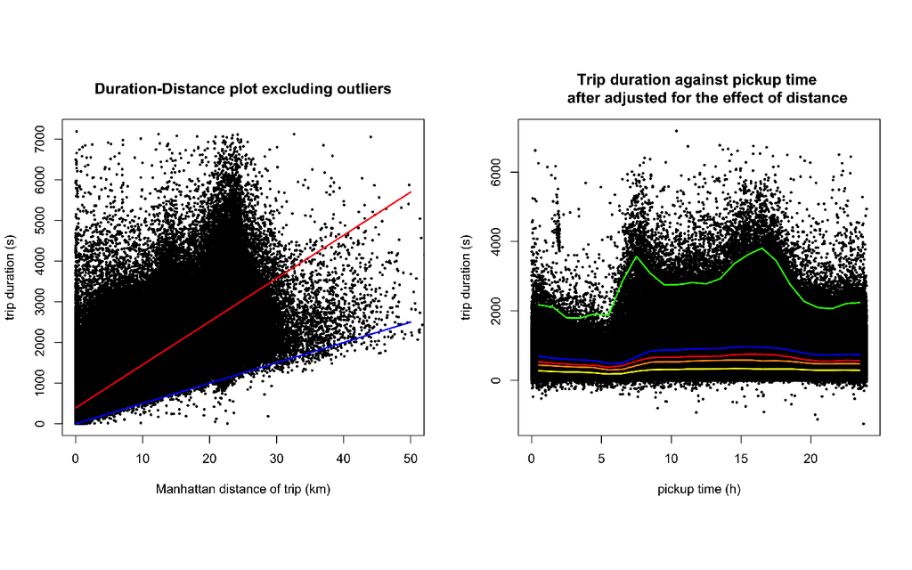

A second concern is that date might also play a role in the variation at the same time point. Workdays and weekends can differ, so does sunny days and rainy or snowy days, but for that purpose we need extra data on weather and road conditions. Our next plots simply exhibits how diffrent days in a week can affect the speed of trips. When training models and making predictions,however, we would use the exact date in a year.

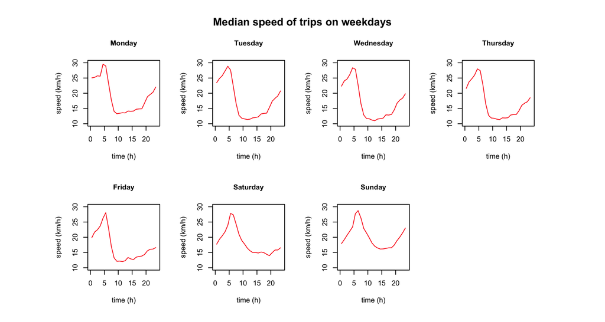

# Tree model

A natural idea is to divide the map into small regions, with each region an estimate about the duration. This idea is based on the assumption that trips with similar features should also have close durations. Tree based methods can fulfill this idea,
$$T(x, \Theta) = \sum_{j=1}^J \gamma_j I(x \in R_j),$$
where T is a function that takes value $\gamma_j$ over region $R_j$.

In our case, the entire space has 6 dimensions: x = (pickup_longitude, pickup_latitude, dropoff_longitude, dropoff_latitude, date, time) and we adopt the boosted tree model (sum of $M$ trees) to build a ‘sophiscated tree’ that may have good prediction of duration,
$$f_M (x) = \sum_{m=1}^M T(x, \Theta_m).$$
A newly-added tree is decided by the former trees (a forward stagewise manner) through minimizing the loss function, that is,
$$\hat \Theta_m = \textit{arg min}_{\Theta_m} \sum_{i=1}^N L\left(y_i, f_{m-1} (x_i) + T(x_i, \Theta_m)\right),$$
where $N$ is the number of samples, $y_i$ is trip duration, and for loss function $L$ we use the evaluation formular of RSMLE (Root Mean Squared Logarithmic Error) suggested by kaggle:
$$L(y, \hat y) = [\log(y+1) - \log(\hat{y}+1)]^2$$
The model is fitted via gradient boosting. At each step, a regression tree is fitted in a way to approximate the negative gradient and then added to the current tree.